# deca_16S_ancombc

Dylan Barth

2025-12-18

## Import the phyloseq object

Here we make use of the highly integrated phyloseq data type. The phyloseq object we built previously plugs directly into ANCOMBC with minimal preprocessing. The one minimal step we need to take before each run of `ancombc2()` is to create a single `Group` variable that accounts for the combination we are interested in. The first example combines `Microhabitat` and `SampleDate` and is used to detect structural zeroes.

Structural zeroes are a special case of differential abundance, wherein a taxa (class, order, phylum, etc.) is completely absent from one group. In ancombc2, the software preprocesses these taxa and filters them out, so the `Group` variable should map to the same samples as the formula in the kwarg `fix_formula=`. Ultimately the choice of independent variable here will determine the sample size within each group, so we conclude by checking the sample sizes of each group.

```r
ps <- readRDS('data/16Sdada2/phyloseq.filtered.rds')
meta <- sample_data(ps)
sample_data(ps)$Group <- data.frame(meta) %>%
  mutate(Group=paste(Microhabitat, SampleDate, sep='_') ) %>%
  pull(Group)
#check the size of groups briefly to ensure high N
data.frame(sample_data(ps)) %>% group_by(Group) %>% summarize(n=n()) %>% arrange(n) %>% ht()
```

```
## $HEAD
## # A tibble: 5 × 2
##   Group            n
##   <chr>        <int>
## 1 SSG_Jul_2022     2
## 2 SI_Jul_2022      7
## 3 SG_Jul_2022     10
## 4 SSI_Jul_2022    10
## 5 SI_Nov_2023     31
##
## $TAIL
## # A tibble: 5 × 2
##   Group            n
##   <chr>        <int>
## 1 SSG_Aug_2023    40
## 2 SSG_Nov_2022    40
## 3 SSI_Aug_2023    40
## 4 SSI_Feb_2023    40
## 5 SSI_Nov_2022    40
```

```r
#filter low sample size
ps <- subset_samples(ps, SampleDate != "Jul_2022")
ps <- prune_taxa(taxa_sums(ps)>0,ps)
```

## Run ancombc2 microhabitat contrast

We also set `tax_level='Phylum'` to define the taxonomic level at which to group ASVs. Depending on the fidelity of the data/annotation, this value can be scaled all the way back to ‘Phylum’, but may not be informative at a wider scope.

This operation is a well optimized piece of software, but we still need to take care to not overload our HPC with such a large dataset. The main concern is running near RAM limits, as holding a large ~45,000 x ~900 ASV matrix in memory is not optimal. Two parameters can be tuned to effectively limit the memory requirements: `prv_cut` which excludes ASVs below the stated prevalence threshold [0,1], making the matrix itself smaller. The other, `n_cl` controls the number of nodes to be forked during parallel processing. Each node here needs to do operations upon this matrix and pulls it into memory, so increasing this number can quickly balloon your RAM usage.

```r
#run with just microhabitat comparison to start
out <- ancombc2(data = ps,
               fix_formula='Treatment+SampleDate+Microhabitat',
               rand_formula = NULL,
               tax_level="Phylum",
               p_adj_method = 'holm',
               prv_cut = 0.1,
               n_cl = 12,
               group='Microhabitat',
               pairwise = T,
               struc_zero = T,
               neg_lb = F)

#save
saveRDS(out, 'data/16Sancombc/ancombc.mh.out.rds')
```

## Make Volcano plots

Visualize the significant taxa with some volcano plots.

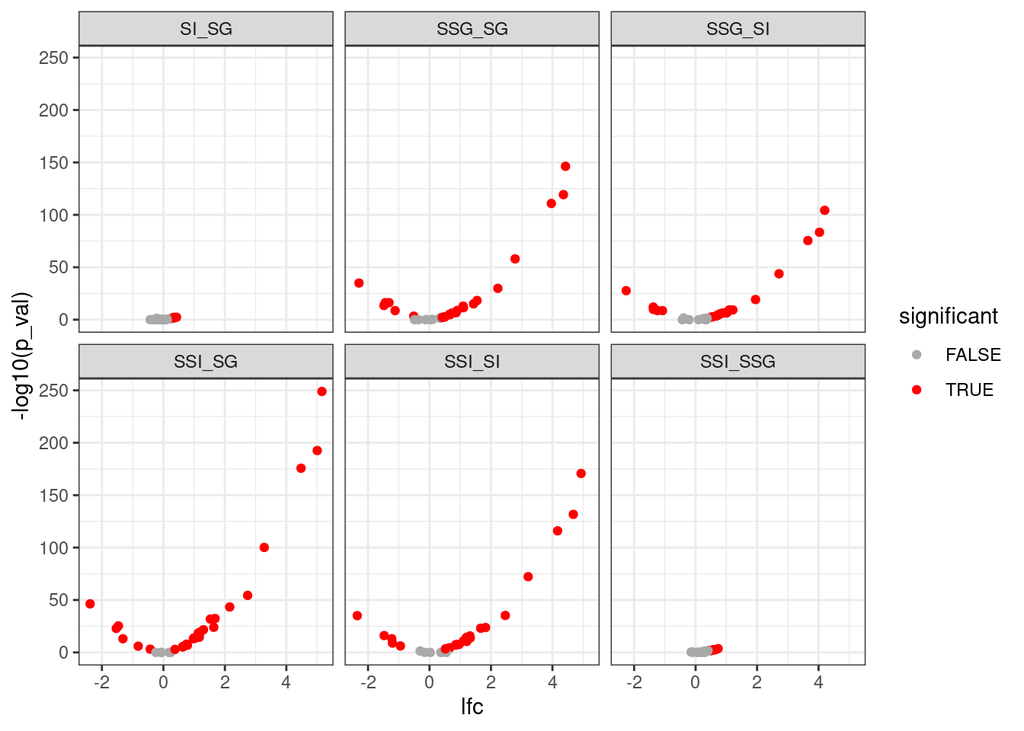

```r
res <- out$res_pair %>% select(starts_with(c('tax',"lfc","diff", "p")))

res_long <- res %>%
  #rename implicit cols to make reference column explicit
  rename_with(
    ~{
      x <- .x
      term <- "Microhabitat"
      ref <- "SG"
      #ex: lfc_MicrohabitatSI  -> lfc_MicrohabitatSI_MicrohabitatSG
      x <- str_replace(
        x,
        paste0("^(lfc|diff|p)_", term, "([A-Za-z0-9]+)$"),
        paste0("\\1_", term, "\\2_", term, ref)
      )

      #clean up
      x <- str_replace_all(x, paste0(term), "")
      x <- str_replace(x, "^p_", "p_val_")

      #return object
      x
    },
    .cols = -taxon
  ) %>%
  #pivot longer for graphing purposes
  pivot_longer(
    cols = -taxon,
    names_to = c(".value", "contrast"),
    names_pattern = "^(lfc|diff|p_val)_(.+)$"
  ) %>%
  #clean up hanging chads
  mutate(
    contrast = str_replace_all(contrast, "^_", ""),
    contrast = str_replace_all(contrast, "__+", "_")
  )

ggplot(res_long)+
  geom_point(aes(x=lfc,y=-log10(p_val),color=diff))+
  theme_bw()+
  facet_wrap(~contrast)+
  guides(color=guide_legend(title="significant") )+
  scale_color_manual(values = c("darkgrey","red"))
```

```r
write_csv(res_long,'data/16Sancombc/ancombc_results_mh.csv')
```

## Significant taxa heatmaps

We can see from many of our previous results that there is a much larger distinction between surface depth than there is between grass/interspace. For that reason, we focus in on comparisons between the same local microhabitat (G/I) that differ in depth (e.g. SSG_SG and SSI_SI). We use a heatmap to visualize the lfc scores across groups. We also print a table of structural zeroes identified between groups, which is useful for identifying indicator species. Interestingly, no species were identified as structural zeroes within the SSI group, meaning all identified organisms were found at least once in an SSI sample. It is important to note that becaue of `prv_cut=0.1`, all structural zeroes are species that have at least 10% prevalence in at least one sample, so rare taxa are not as well captured by this test.

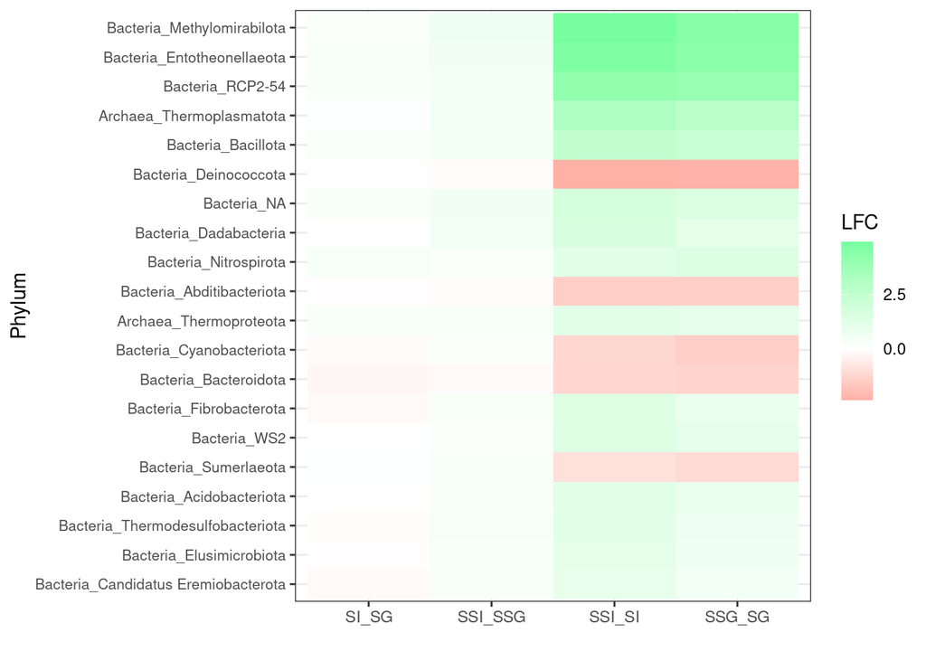

```r
contrasts_keep <- c("SSI_SI", "SSG_SG")
alpha <- 0.05
sig_taxa <- res_long %>%
  filter(contrast %in% contrasts_keep, !is.na(p_val), !is.na(diff)) %>%
  filter(p_val < alpha) %>%
  group_by(taxon) %>%
  summarise(max_abs_lfc = max(abs(lfc), na.rm = TRUE), .groups = "drop") %>%
  arrange(-max_abs_lfc) %>%
  head(n=20) %>%
  pull(taxon)

gdat <- res_long %>%
  filter(taxon %in% sig_taxa) %>%
  mutate(
    sig = p_val < alpha,
    taxon = fct_reorder(taxon, abs(lfc), .fun = max, .desc = F), #order by abs(lfc)
    contrast = factor(contrast, levels=c("SI_SG","SSI_SSG","SSI_SI","SSG_SG","SSI_SG","SSG_SI"))
  )

ggplot(gdat %>% filter(contrast %in% c("SI_SG","SSI_SSG","SSI_SI","SSG_SG"))) +
  geom_tile(aes(x = contrast, y = taxon, fill = lfc)) +
  scale_fill_gradient2(low = "#FE504D",mid = "white", high = "#76FE9F", midpoint = 0)+
  theme_bw() +
  theme(axis.text.y = element_text(size = 8)) +
  labs(fill = "LFC")+
  xlab("")+
  ylab("Phylum")
```

```r
zeros <- out$zero_ind
colnames(zeros) <- c('taxon','SG','SI','SSG','SSI')
zeros %>% filter(SG|SI|SSG|SSI)
```

```
##                            taxon    SG    SI   SSG   SSI
## 1               Bacteria_FCPU426 FALSE  TRUE FALSE FALSE
## 2         Bacteria_Spirochaetota FALSE  TRUE  TRUE FALSE
## 3          Bacteria_Synergistota  TRUE  TRUE  TRUE FALSE
## 4                 Bacteria_GAL15  TRUE  TRUE FALSE FALSE
## 5        Bacteria_Incertae Sedis  TRUE FALSE FALSE FALSE
## 6  Bacteria_Rs-K70 termite group  TRUE  TRUE  TRUE FALSE
## 7                 Bacteria_NB1-j  TRUE  TRUE FALSE FALSE
## 8      Archaea_Methanobacteriota  TRUE  TRUE  TRUE FALSE
## 9        Bacteria_Cloacimonadota  TRUE  TRUE  TRUE FALSE
## 10              Bacteria_TX1A-33  TRUE  TRUE  TRUE FALSE
## 11       Archaea_Aenigmarchaeota  TRUE FALSE FALSE FALSE
```

## Run ancombc2 treatment contrast

Here we run the model to catch any differences in treatment. The large number of groups increases the number of tests that are performed, and narrows the sample size in each group, which makes statistical significance harder to reach. Because of this, fewer taxa are reported as significant, but we can still find usefulness in the order of their LFC scores and the structural zeroes that are identified.

```r
#run with just treatment comparison
out <- ancombc2(data = ps,
               fix_formula='Treatment+SampleDate+Microhabitat',
               rand_formula = NULL,
               tax_level="Phylum",
               p_adj_method = 'holm',
               prv_cut = 0.1,
               n_cl = 12,
               group='Treatment',
               pairwise = T,
               struc_zero = T,
               neg_lb = F)

#save
saveRDS(out, 'data/16Sancombc/ancombc.treat.out.rds')
```

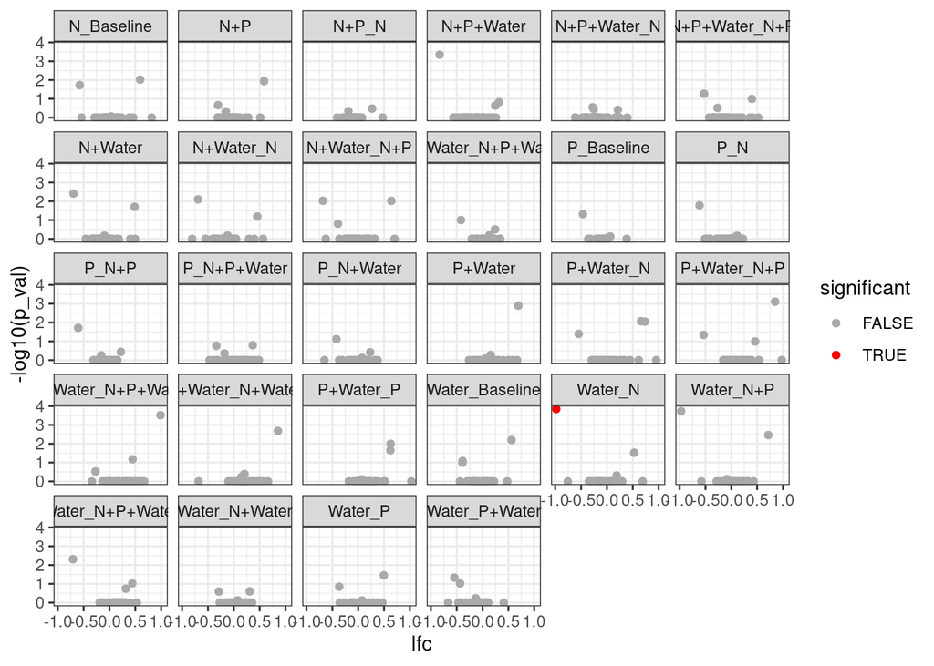

```r
res <- out$res_pair %>% select(starts_with(c('tax',"lfc","diff", "p")))

res_long <- res %>%
  #rename implicit cols to make reference column explicit
  rename_with(
    ~{
      x <- .x
      term <- "Treatment"
      ref <- "Baseline"
      #ex: lfc_MicrohabitatSI  -> lfc_MicrohabitatSI_MicrohabitatSG
      x <- str_replace(
        x,
        paste0("^(lfc|diff|p)_", term, "([A-Za-z0-9]+)$"),
        paste0("\\1_", term, "\\2_", term, ref)
      )

      #clean up
      x <- str_replace_all(x, paste0(term), "")
      x <- str_replace(x, "^p_", "p_val_")

      #return object
      x
    },
    .cols = -taxon
  ) %>%
  #pivot longer for graphing purposes
  pivot_longer(
    cols = -taxon,
    names_to = c(".value", "contrast"),
    names_pattern = "^(lfc|diff|p_val)_(.+)$"
  ) %>%
  #clean up hanging chads
  mutate(
    contrast = str_replace_all(contrast, "^_", ""),
    contrast = str_replace_all(contrast, "__+", "_")
  )

ggplot(res_long)+
  geom_point(aes(x=lfc,y=-log10(p_val),color=diff))+
  theme_bw()+
  facet_wrap(~contrast)+
  guides(color=guide_legend(title="significant") )+
  scale_color_manual(values = c("darkgrey","red"))
```

```r
write_csv(res_long,'data/16Sancombc/ancombc_results_treat.csv')
```

## Treatment significant taxa and structural zeroes

Since the treatment category has so many variables, almost nothing is significant. However one phyla, Bacteria_Deinococcota, is significantly enriched when comparing Nitrogen to Water treatments. There are some structural zeroes that are interesting as well, particularly Archaea_Aenigmarchaeota which only shows up in treatments containing both water and phosphorous. Bacteria_Cloacimonadota, Archaea_Methanobacteriota, and Bacteria_Rs-K70 termite group only show up in the phosphorous-only treatment, and Bacteria_Hydrogenedentes was absent only from the phosphorous-only treatments. The number of structural zeroes in each treatment group is also calculated, with the highest number identified in N+Water treatment groups.

```r
res_long %>% filter(diff)
```

```
## # A tibble: 1 × 5
##   taxon                 contrast    lfc diff     p_val
##   <chr>                 <chr>     <dbl> <lgl>    <dbl>
## 1 Bacteria_Deinococcota Water_N  -0.981 TRUE  0.000142
```

```r
zeros <- out$zero_ind
colnames(zeros) <- c('taxon','Control','N','N+P','N+P+Water','N+Water','P','P+Water','Water')
zeros %>% filter(Control|N|N+P|N+P+Water|N+Water|P|P+Water|Water)
```

```
##                            taxon Control     N   N+P N+P+Water N+Water     P
## 1       Bacteria_Hydrogenedentes   FALSE FALSE FALSE     FALSE   FALSE  TRUE
## 2         Bacteria_Spirochaetota   FALSE FALSE  TRUE      TRUE    TRUE FALSE
## 3          Bacteria_Synergistota   FALSE  TRUE  TRUE      TRUE    TRUE FALSE
## 4                 Bacteria_GAL15   FALSE  TRUE FALSE     FALSE    TRUE  TRUE
## 5        Bacteria_Incertae Sedis   FALSE FALSE  TRUE     FALSE   FALSE  TRUE
## 6  Bacteria_Rs-K70 termite group    TRUE  TRUE  TRUE      TRUE    TRUE FALSE
## 7                 Bacteria_NB1-j   FALSE FALSE FALSE     FALSE    TRUE FALSE
## 8      Archaea_Methanobacteriota    TRUE  TRUE  TRUE      TRUE    TRUE FALSE
## 9        Bacteria_Cloacimonadota    TRUE  TRUE  TRUE      TRUE    TRUE FALSE
## 10              Bacteria_TX1A-33    TRUE  TRUE  TRUE      TRUE    TRUE  TRUE
## 11       Archaea_Aenigmarchaeota    TRUE  TRUE  TRUE     FALSE    TRUE  TRUE
##    P+Water Water
## 1    FALSE FALSE
## 2     TRUE  TRUE
## 3     TRUE  TRUE
## 4    FALSE FALSE
## 5    FALSE FALSE
## 6     TRUE  TRUE
## 7    FALSE  TRUE
## 8     TRUE  TRUE
## 9     TRUE  TRUE
## 10    TRUE FALSE
## 11   FALSE  TRUE
```

```r
colSums(zeros[2:length(zeros)])
```

```
##   Control         N       N+P N+P+Water   N+Water         P   P+Water     Water
##         5         7         8         6         9         5         6         7
```